# PLAID: ultrafast single-sample enrichment scoring

BigOmics Analytics

26 August 2025

#### Package

plaid 0.1.0.9001

# 1 Introduction

We developed PLAID (Pathway Level Average Intensity Detection), a novel, ultrafast and memory optimized gene set scoring algorithm. PLAID demonstrates accurate gene set scoring and outperforms all currently available gene set scoring methods in large bulk and single-cell RNA-seq datasets.

# 2 Installing ‘plaid’

The most updated version of ‘plaid’ is hosted on GitHub and can be easily installed using devtools::install_github() function provided by

```r
# devtools::install_github('bigomics/plaid')
```

# 3 Example: Single-cell RNA-seq hallmark scoring

## 3.1 Preparing data

For this vignette, our package includes a small subset of the the pmbc3k single-cell dataset of just 50 cells. Please install the Seurat and SeuratData packages if you want to run this vignette against the full dataset.

```r
library("plaid")
load(system.file("extdata", "pbmc3k-50cells.rda", package = "plaid"),verbose=TRUE)
```

```
#> Loading objects:
#>   X
#>   celltype
```

```r
dim(X)
```

[output not shown]

Note that X is the normalized expression matrix form the Seurat object, not the raw counts matrix. We recommend to run Plaid on the log transformed expression matrix, not on the counts, as the average in the logarithmic space is more robust and is in concordance to calculating the geometric mean.

It is not necessary to normalize your expression matrix before running plaid because plaid normalizes the enrichment scores afterwards. However, again, log transformation is recommended.

It is recommended to keep the expression matrix sparse as much as possible because plaid extensively take advantage of sparse matrix computations. But even for dense matrices plaid is fast.

## 3.2 Preparing gene sets

For convenience we have included the 50 Hallmark genesets in our package. But we encourage you to download larger geneset collections as Plaid’s speed advantage will be more apparent for larger datasets and large geneset collections.

Plaid needs the gene sets as sparse matrix. If you have your collection of gene sets a a list, we need first to convert the gmt list to matrix format.

```r
hallmarks <- system.file("extdata", "hallmarks.gmt", package = "plaid")
gmt <- read.gmt(hallmarks)
matG <- gmt2mat(gmt)
dim(matG)
```

```
#> [1] 4386   50
```

If you have your own gene sets stored as gmt files, you can conveniently use the included `read.gmt()` function to read the gmt file.

## 3.3 Calculating the score

The main function to run plaid is `plaid()`. We run plaid on our expression matrix `X` and gene set matrix `matG`.

```r
gsetX <- plaid(X, matG, normalize=TRUE)
dim(gsetX)
```

```
#> [1] 50 50
```

The resulting matrix `gsetX` contains the single-sample enrichment scores for the specified gene sets and samples.

Notice that by default plaid performs median normalization of the final results. That also means that it is not necessary to normalize your expression matrix before running plaid. However, generally, log transformation is recommended.

Plaid can also be run on the ranked matrix, we will see later that this corresponds to the singscore (Fouratan et al., 2018). Or plaid could be run on the (non-logarithmic) counts which can be used to calculate the scSE score (Pont et al., 2019).

## 3.4 Very large matrices

Plaid is fast and memery efficient because it uses very efficient sparse matrix computation in the back. For very large `X`, plaid uses chunked computation by splitting the matrix in chunks to avoid index overflow. Should you encounter errors, please compute your dataset by subsetting manually the expression matrix and/or gene sets.

Although `X` and `matG` are generally very sparse, be aware that the result matrix `gsetX` generally is dense and therefore can become very large. If you would want to compute the score of 10.000 gene sets on a million of cells this would create a large 10.000 x 1.000.000 dense matrix which requires about 75GB of memory.

## 3.5 Performing a differential expression test

Once we have the gene sets scores we can use these scores for statistical analysis. We could compute the differential gene set expression between two groups using a general t-test or limma directly on the score matrix `gsetX`.

Another way to test whether a gene set is statistically significant would be to test whether the fold-change of the genes in the gene sets are statistically different than zero. That is, we can perform a one sample t-test on the logFC of the genes of each gene sets and test whether they are significantly different from zero. The logFC is computed from the original (log) expression matrix `X` and group vector `y`.

The function `dual_test()` does both tests: the one-sample t-test on the logFC and the two-group t-test on the gene set matrix `gsetX`.

```r
y <- 1*(celltype == "B")
res <- dual_test(X, y, matG, gsetX=gsetX)
```

The top significant genesets can be shown with

```r
res <- res[order(res[,"p.dual"]),]
head(res)
```

```
#>                                         gsetFC size         p.fc         p.ss
#> HALLMARK_INTERFERON_GAMMA_RESPONSE  0.09923298  155 5.614052e-06 1.067381e-05
#> HALLMARK_ALLOGRAFT_REJECTION        0.08322962  134 5.162037e-04 1.311508e-05
#> HALLMARK_P53_PATHWAY               -0.04702449  130 1.378624e-02 2.900893e-04
#> HALLMARK_INTERFERON_ALPHA_RESPONSE  0.09705679   78 1.653989e-03 9.406415e-03
#> HALLMARK_ANGIOGENESIS              -0.14291289    4 5.680258e-02 6.098317e-02
#> HALLMARK_IL2_STAT5_SIGNALING        0.02905553  107 3.781802e-01 3.704478e-03
#>                                          p.dual       q.dual
#> HALLMARK_INTERFERON_GAMMA_RESPONSE 4.948006e-10 2.474003e-08
#> HALLMARK_ALLOGRAFT_REJECTION       6.014977e-08 1.503744e-06
#> HALLMARK_P53_PATHWAY               3.290696e-05 5.484494e-04
#> HALLMARK_INTERFERON_ALPHA_RESPONSE 9.262597e-05 1.157825e-03
#> HALLMARK_ANGIOGENESIS              1.347047e-02 1.157300e-01
#> HALLMARK_IL2_STAT5_SIGNALING       1.730306e-02 1.157300e-01
```

We can also show the results as a volcano plot:

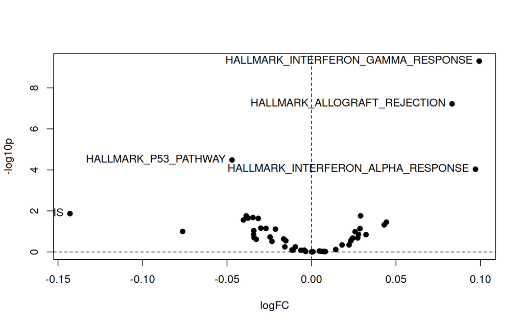

```r
fc <- res[,"gsetFC"]
pv <- res[,"p.dual"]
plot( fc, -log10(pv), xlab="logFC", ylab="-log10p", pch=19)
abline(h=0, v=0, lty=2)
text( fc[1:5], -log10(pv[1:5]), rownames(res)[1:5],pos=2)
```

# 4 Replicating ssGSEA, singscore and scSE

Plaid can be used to replicated the singscore (Fouratan et al., 2018) and Single-Cell Signature Explorer (scSE) score (Pont et al., 2019). But using plaid, the computation is much faster than the original code.

## 4.1 Replicating singscore

Computing the singscore requires to compute the ranks of the expression matrix. We have wrapped this in a single convenience function:

```r
sing <- replaid.sing(X, matG)
```

We have extensively compared the results of `replaid.sing` and from the original `singscore` R package and we showed identical result in the score, logFC and p-values.

## 4.2 Replicating ssGSEA

Plaid can also be used to compute the ssGSEA score (Barbie et al., 2009). Using plaid, we can calculate the score upto 100x faster. We have wrapped this in a single convenience function:

```r
ssgsea <- replaid.ssgsea(X, matG, alpha=0)
```

We have extensively compared the results of `replaid.ssgsea()` and from the original `GSVA` R package. Note the rank weight parameter alpha. For `alpha=0` we obtained identical result for the score, logFC and p-values. For non-zero values for alpha the results are close but not exactly the same. The default value in the original publication and in GSVA is `alpha=0.25`.

## 4.3 Replicating the scSE score

Computing the scSE requires running plaid on the linear (not logarithmic) score and perform additional normalization by the total UMI per sample. We have wrapped this in a single convenience function:

```r
scse <- replaid.scse(X, matG, removeLog2=TRUE, scoreMean=FALSE)
```

```
#> [replaid.scse] Converting data to linear scale (removing log2)...
```

To replicate the original “sum-of-UMI” scSE score, set `removeLog2=TRUE` and `scoreMean=FALSE`. scSE and plaid scores become more similar for `removeLog2=FALSE` and `scoreMean=TRUE`.

We have extensively compared the results from `replaid.scse` and from the original scSE (implemented in GO lang) and we showed almost identical results in the score, logFC and p-values.

## 4.4 Compare scores

We can compare all scores in a pairs plot:

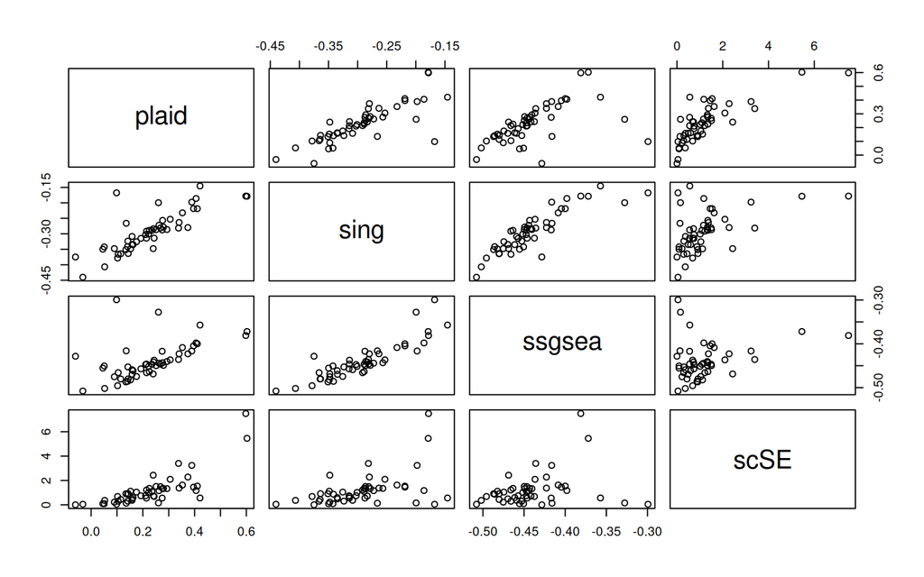

```r
S <- cbind(plaid=gsetX[,1], sing=sing[,1], ssgsea=ssgsea[,1], scSE=scse[,1])
pairs(S)
```